# EDA Zestawu danych - Titanic

## O Danych

Dane o pasażerach Titanica

Zbiór danych zawiera informacje o pasażerach RMS Titanic, który zatonął 15 kwietnia 1912 roku po zderzeniu z górą lodową. Dane obejmują takie atrybuty jak klasa podróży, wiek, płeć, liczba rodzeństwa/małżonków na pokładzie, liczba rodziców/dzieci na pokładzie, cena biletu oraz miejsce zaokrętowania.

Zbiór zawiera także informację o tym, czy pasażer przeżył katastrofę.

Titanic przewoził ponad 2,200 osób, z czego ponad 1,500 zginęło, co czyni tę katastrofę jedną z najbardziej tragicznych w historii morskiej.

Kolumny:

- **pclass** - Klasa biletu
- **survived** - Czy pasażer przeżył katastrofę
- **name** - Imię i nazwisko pasażera
- **sex** - Płeć pasażera
- **age** - Wiek pasażera
- **sibsp** - Liczba rodzeństwa/małżonków na pokładzie
- **parch** - Liczba rodziców/dzieci na pokładzie
- **ticket** - Numer biletu
- **fare** - Cena biletu
- **cabin** - Numer kabiny
- **embarked** - Port, w którym pasażer wszedł na pokład (C = Cherbourg, Q = Queenstown, S = Southampton)
- **boat** - Numer łodzi ratunkowej
- **body** - Numer ciała (jeśli pasażer nie przeżył i ciało zostało odnalezione)
- **home.dest** - Miejsce docelowe

### Zapraszam na moją analize danych dotyczącą pasażerów Titanica.

### Spróbuję odpowiedzieć na pytanie o przeżywalność pasażerów rejsu.

[figure not shown]

## 1) Wstepna inspekcja danych:

Dane zawierają **1310** wierszy i **14** kolumn.

### Ogólny przegląd:

|  | pclass | survived | name | sex | age | sibsp | parch | ticket | fare | cabin | embarked | boat | body | home.dest |
| --- | --- | --- | --- | --- | --- | --- | --- | --- | --- | --- | --- | --- | --- | --- |
| 1206 | 3.0 | 0.0 | Skoog, Master. Harald | male | 4.0000 | 3.0 | 2.0 | 347088 | 27.9000 | NaN | S | NaN | NaN | NaN |
| 55 | 1.0 | 1.0 | Carter, Miss. Lucile Polk | female | 14.0000 | 1.0 | 2.0 | 113760 | 120.0000 | B96 B98 | S | 4 | NaN | Bryn Mawr, PA |
| 64 | 1.0 | 1.0 | Chambers, Mr. Norman Campbell | male | 27.0000 | 1.0 | 0.0 | 113806 | 53.1000 | E8 | S | 5 | NaN | New York, NY / Ithaca, NY |
| 306 | 1.0 | 0.0 | White, Mr. Percival Wayland | male | 54.0000 | 0.0 | 1.0 | 35281 | 77.2875 | D26 | S | NaN | NaN | Brunswick, ME |
| 784 | 3.0 | 0.0 | Dyker, Mr. Adolf Fredrik | male | 23.0000 | 1.0 | 0.0 | 347072 | 13.9000 | NaN | S | NaN | NaN | West Haven, CT |
| 519 | 2.0 | 0.0 | Norman, Mr. Robert Douglas | male | 28.0000 | 0.0 | 0.0 | 218629 | 13.5000 | NaN | S | NaN | 287.0 | Glasgow |
| 213 | 1.0 | 1.0 | Newell, Miss. Madeleine | female | 31.0000 | 1.0 | 0.0 | 35273 | 113.2750 | D36 | C | 6 | NaN | Lexington, MA |
| 1174 | 3.0 | 0.0 | Sage, Miss. Dorothy Edith "Dolly" | female | NaN | 8.0 | 2.0 | CA. 2343 | 69.5500 | NaN | S | NaN | NaN | NaN |
| 1162 | 3.0 | 1.0 | Ryan, Mr. Edward | male | NaN | 0.0 | 0.0 | 383162 | 7.7500 | NaN | Q | 14 | NaN | NaN |
| 534 | 2.0 | 1.0 | Phillips, Miss. Kate Florence ("Mrs Kate Louis... | female | 19.0000 | 0.0 | 0.0 | 250655 | 26.0000 | NaN | S | 11 | NaN | Worcester, England |
| 300 | 1.0 | 0.0 | Van der hoef, Mr. Wyckoff | male | 61.0000 | 0.0 | 0.0 | 111240 | 33.5000 | B19 | S | NaN | 245.0 | Brooklyn, NY |
| 590 | 2.0 | 1.0 | West, Miss. Barbara J | female | 0.9167 | 1.0 | 2.0 | C.A. 34651 | 27.7500 | NaN | S | 10 | NaN | Bournmouth, England |
| 230 | 1.0 | 1.0 | Perreault, Miss. Anne | female | 30.0000 | 0.0 | 0.0 | 12749 | 93.5000 | B73 | S | 3 | NaN | NaN |
| 769 | 3.0 | 0.0 | Dennis, Mr. Samuel | male | 22.0000 | 0.0 | 0.0 | A/5 21172 | 7.2500 | NaN | S | NaN | NaN | NaN |
| 515 | 2.0 | 1.0 | Navratil, Master. Michel M | male | 3.0000 | 1.0 | 1.0 | 230080 | 26.0000 | F2 | S | D | NaN | Nice, France |
| 585 | 2.0 | 0.0 | Weisz, Mr. Leopold | male | 27.0000 | 1.0 | 0.0 | 228414 | 26.0000 | NaN | S | NaN | 293.0 | Bromsgrove, England / Montreal, PQ |
| 128 | 1.0 | 0.0 | Gee, Mr. Arthur H | male | 47.0000 | 0.0 | 0.0 | 111320 | 38.5000 | E63 | S | NaN | 275.0 | St Anne's-on-Sea, Lancashire |
| 78 | 1.0 | 1.0 | Compton, Mrs. Alexander Taylor (Mary Eliza Ing... | female | 64.0000 | 0.0 | 2.0 | PC 17756 | 83.1583 | E45 | C | 14 | NaN | Lakewood, NJ |
| 866 | 3.0 | 1.0 | Hirvonen, Miss. Hildur E | female | 2.0000 | 0.0 | 1.0 | 3101298 | 12.2875 | NaN | S | 15 | NaN | NaN |
| 1152 | 3.0 | 0.0 | Robins, Mr. Alexander A | male | 50.0000 | 1.0 | 0.0 | A/5. 3337 | 14.5000 | NaN | S | NaN | 119.0 | NaN |

### Wartości unikalne & typy danych:

```
pclass          3
survived        2
name         1307
sex             2
age            98
sibsp           7
parch           8
ticket        929
fare          281
cabin         186
embarked        3
boat           27
body            2
home.dest     369
dtype: int64
```

```
pclass       float64
survived     float64
name          object
sex           object
age          float64
sibsp        float64
parch        float64
ticket        object
fare         float64
cabin         object
embarked      object
boat          object
body         float64
home.dest     object
dtype: object
```

## 2) Czyszczenie i transformacja danych:

```
pclass          0
survived        0
name            0
sex             0
age           263
sibsp           0
parch           0
ticket          0
fare            1
cabin        1014
embarked        2
boat          823
body         1188
home.dest     564
dtype: int64
```

|  | pclass | survived | name | sex | age | sibsp | parch | ticket | fare | cabin | embarked | boat | body | home.dest |
| --- | --- | --- | --- | --- | --- | --- | --- | --- | --- | --- | --- | --- | --- | --- |
| 906 | 3 | False | Jonsson, Mr. Nils Hilding | male | 27.0 | 0 | 0 | 350408 | 7.8542 | NaN | S | NaN | True | NaN |
| 707 | 3 | False | Carlsson, Mr. August Sigfrid | male | 28.0 | 0 | 0 | 350042 | 7.7958 | NaN | S | NaN | True | Dagsas, Sweden Fower, MN |
| 479 | 2 | True | Laroche, Miss. Simonne Marie Anne Andree | female | 3.0 | 1 | 2 | SC/Paris 2123 | 41.5792 | NaN | C | 14 | False | Paris / Haiti |
| 126 | 1 | False | Futrelle, Mr. Jacques Heath | male | 37.0 | 1 | 0 | 113803 | 53.1000 | C123 | S | NaN | True | Scituate, MA |
| 1083 | 3 | False | Olsen, Mr. Henry Margido | male | 28.0 | 0 | 0 | C 4001 | 22.5250 | NaN | S | NaN | True | NaN |

```
pclass         int32
survived        bool
name          object
sex           object
age          float64
sibsp          int32
parch          int32
ticket        object
fare         float64
cabin         object
embarked      object
boat          object
body            bool
home.dest     object
dtype: object
```

## 3) Analiza jednowymiarowa:

|  | pclass | age | sibsp | parch | fare |
| --- | --- | --- | --- | --- | --- |
| count | 1309.000000 | 1046.000000 | 1309.000000 | 1309.000000 | 1308.000000 |
| mean | 2.294882 | 29.881135 | 0.498854 | 0.385027 | 33.295479 |
| std | 0.837836 | 14.413500 | 1.041658 | 0.865560 | 51.758668 |
| min | 1.000000 | 0.166700 | 0.000000 | 0.000000 | 0.000000 |
| 25% | 2.000000 | 21.000000 | 0.000000 | 0.000000 | 7.895800 |
| 50% | 3.000000 | 28.000000 | 0.000000 | 0.000000 | 14.454200 |
| 75% | 3.000000 | 39.000000 | 1.000000 | 0.000000 | 31.275000 |
| max | 3.000000 | 80.000000 | 8.000000 | 9.000000 | 512.329200 |

### Wykresy:

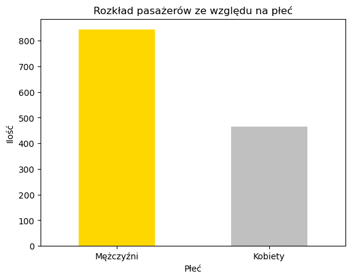

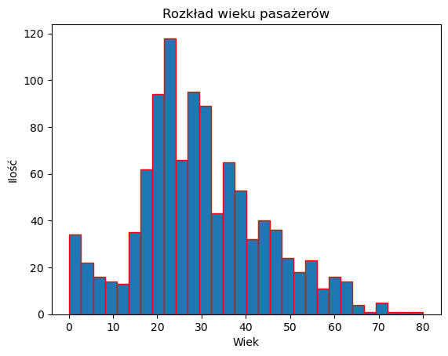

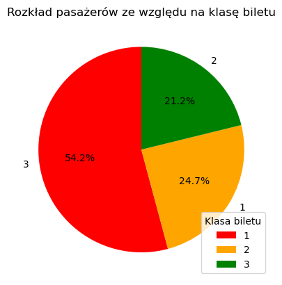

## 4) Analiza dwuwymiarowa:

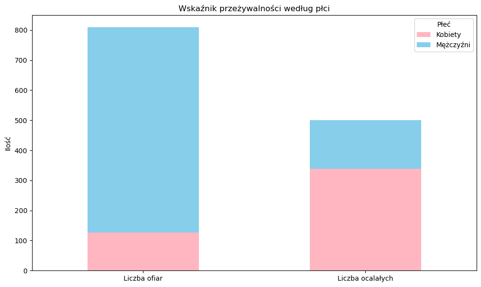

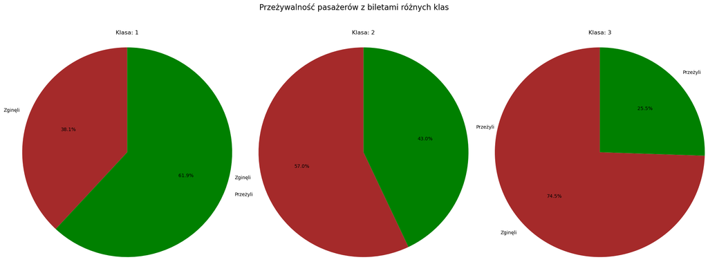

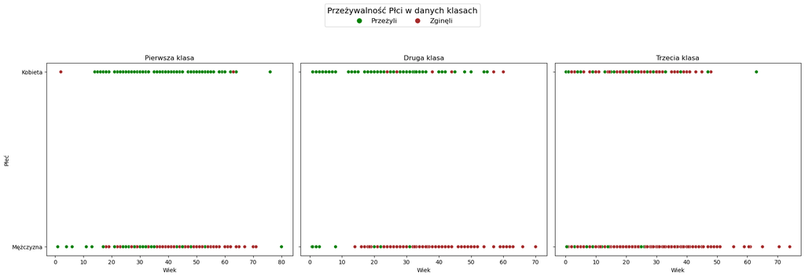

### Sprawdzenie przeżywalności dla najmłodszych pasażerów:

|  | pclass | survived | name | sex | age | sibsp | parch | ticket | fare | cabin | embarked | boat | body | home.dest |
| --- | --- | --- | --- | --- | --- | --- | --- | --- | --- | --- | --- | --- | --- | --- |
| 1 | 1 | True | Allison, Master. Hudson Trevor | male | 0.9167 | 1 | 2 | 113781 | 151.55 | C22 C26 | S | 11 | False | Montreal, PQ / Chesterville, ON |
| 2 | 1 | False | Allison, Miss. Helen Loraine | female | 2.0000 | 1 | 2 | 113781 | 151.55 | C22 C26 | S | NaN | True | Montreal, PQ / Chesterville, ON |
| 53 | 1 | False | Carrau, Mr. Jose Pedro | male | 17.0000 | 0 | 0 | 113059 | 47.10 | NaN | S | NaN | True | Montevideo, Uruguay |
| 54 | 1 | True | Carter, Master. William Thornton II | male | 11.0000 | 1 | 2 | 113760 | 120.00 | B96 B98 | S | 4 | False | Bryn Mawr, PA |
| 55 | 1 | True | Carter, Miss. Lucile Polk | female | 14.0000 | 1 | 2 | 113760 | 120.00 | B96 B98 | S | 4 | False | Bryn Mawr, PA |

```
sex
male      82
female    72
Name: count, dtype: int64
```

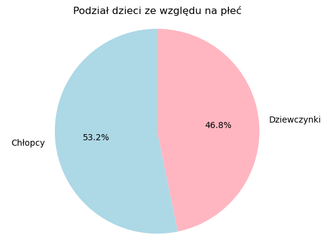

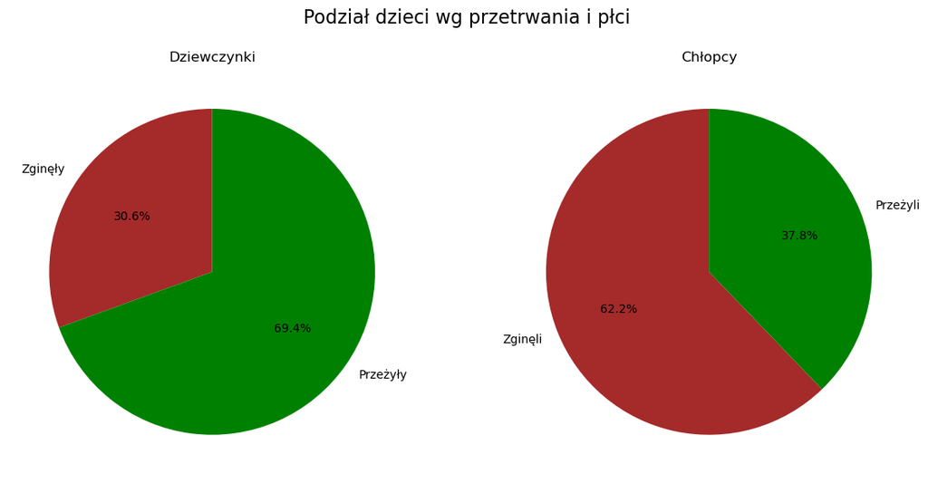

### Sprawdzenie rozkładów i wykrycie wzorców w zbiorze

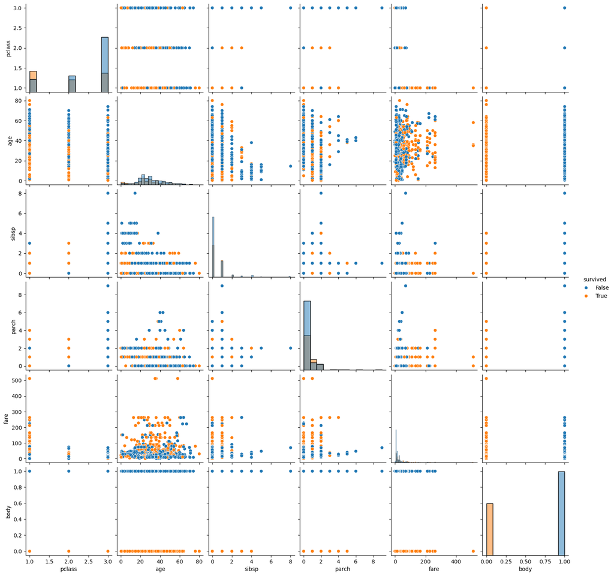

### Sprawdzenie korelacji miedzy kolumnami:

|  | pclass | survived | age | sibsp | parch | fare | body |
| --- | --- | --- | --- | --- | --- | --- | --- |
| pclass | 1.000000 | -0.319979 | -0.411086 | 0.047746 | 0.017685 | -0.565255 | 0.319979 |
| survived | -0.319979 | 1.000000 | -0.053958 | -0.012657 | 0.114091 | 0.249164 | -1.000000 |
| age | -0.411086 | -0.053958 | 1.000000 | -0.243139 | -0.150241 | 0.178739 | 0.053958 |
| sibsp | 0.047746 | -0.012657 | -0.243139 | 1.000000 | 0.374291 | 0.141184 | 0.012657 |
| parch | 0.017685 | 0.114091 | -0.150241 | 0.374291 | 1.000000 | 0.216723 | -0.114091 |
| fare | -0.565255 | 0.249164 | 0.178739 | 0.141184 | 0.216723 | 1.000000 | -0.249164 |
| body | 0.319979 | -1.000000 | 0.053958 | 0.012657 | -0.114091 | -0.249164 | 1.000000 |

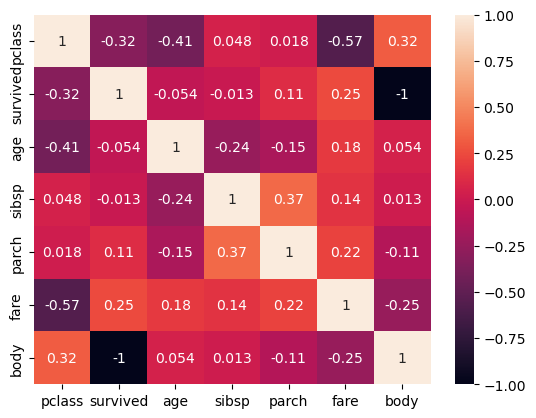

## **Podsumowując, analiza danych pozwala na zrozumienie nie tylko demografii pasażerów,**

## **ale także kluczowych czynników wpływających na przeżywalność w katastrofie.**